# AB plant respones to HF

Cari D. Ficken

2019-05-31

# 1. Load data; calculate CSI

Loading vegetation data (presence/absence) and HF data (% total human development in each plot). Calculate a species specialization index and community specialization index based on the variability in species cumulative occurrences across the binned HF gradient.

Species specialization index (**SSI**) is based on the coefficient of variation of each species’ cumulative occurrence in each disturbance bin. Since we have >1 HF bin which accounts for 0% disturbance, sites end up being randomly assigned into a bin. To account for this, rather than calculating SSI once, we randomize which sites are assinged which bin number, and calculate an SSI with each randomization. The SSI values used hereafter are the means of 1000 randomizations.

The communitity specialization index (**CSI**) is the mean SSI of species present at each site.

*NOTE: I have by necessity altered some site IDs to join them to Lat/Long coordinates. Make sure this was done properly. E.g. Some sites have a “B” after the numerical ID; I removed this “B” to join them to the lat/long database.*

# 2. How does sp richness vary across disturbance gradient?

Species richrichess peaks at intermediate disturbance levels.

Protocol (i.e. wetland vs terrestrial) is a significant predictor of species richness; we include protocol as a fixed effect in all models. Model selection with AIC excluded latitude, longitude, and year from the final model. In the figure below we plot the relationships for each protocol seperately in lighter dashed lines, and the pooled relationship in a thick solid line. To account for sites sampled 2x, we also include site ID as a random effect in all models, regardless of whether it was significant.

| Response | family | link | method | Marginal | Conditional |
| --- | --- | --- | --- | --- | --- |
| rich | gaussian | identity | none | 0.1774766 | 0.6947107 |

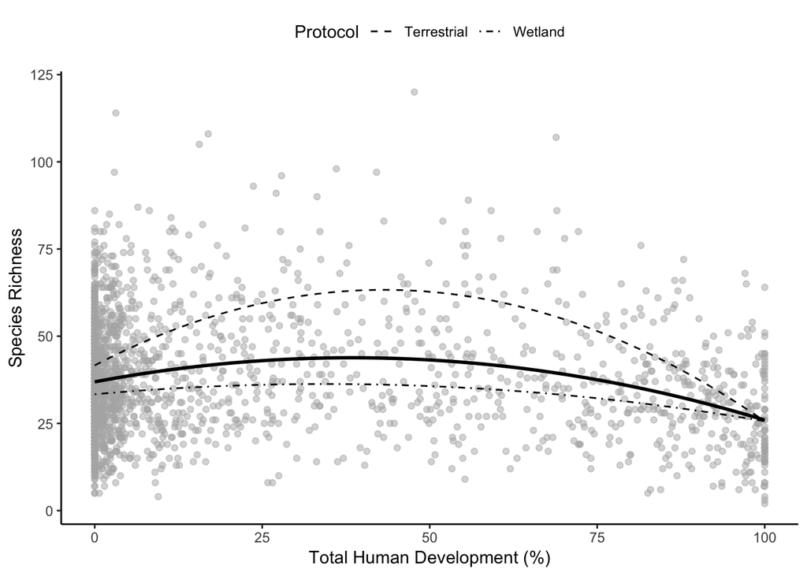

# 3. How do communities differ across disturbance gradient?

### 3.1 The most- and least-disturbed communities differ in community composition

Communities at low and high end of HF gradient show similar plant diversity (richness), but are these communities compositionally different? Yes, MRPP test shows significant difference between these groups and the ordination visualizes this. NMDS with 5 axes has the optimal stress (stress<0.10). __What’s the best way to display the 2 communities? Qualitatively, there is the most difference across axis 1.

Species most strongly associated with sites in the low HF bin (bin 1): (note that these change somewhat b/c so many sites have low HF)

- *Carex oligosperma*: fewseed sedge
- *Drosera anglica*: English sundew
- *Drosera rotundifolia*: Round-leaved sundew
- *Kalmia polifolia*: Bog laurel
- *Rhodondendron tomentosum*: marsh labrador tea

Species most strongly associated with sites in the highest HF bin (bin 10):

- *Avena sativa*: common oat
- *Bromus commutatus*: meadow brome or hairy chess
- *Euphorbia serpyllifolia*: thymeleaf sandmat
- *Bromus commutatus*: meadow brome or hairy chess
- *Hedysarum boreale*: boreal sweetvetch (sometimes top 5)
- *Potentilla supina*: bushy cinquefoil (sometimes top 5)

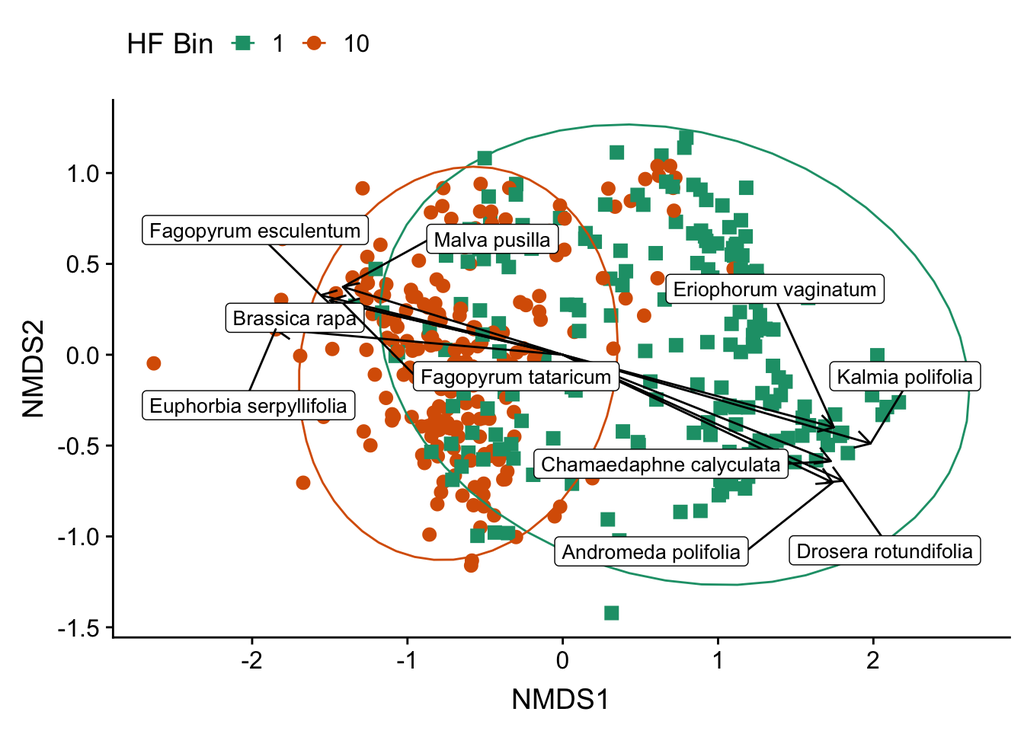

Are communities with intermediate disturbance composed of species found in both the most and least disturbed sites? Or do they have a distinct composition unto themselves?

### 3.3 U-shaped relationshiop between CSI and development

Community specialization index (CSI) is a measure of the mean niche breadth of species within a community. Species which occur with high frequency under a narrow HF are highly specialized and have a narrow niche bread; conversely, species which occur across a range of HF levels are less specialized and have a broader niche breadth.

Plant community CSI shows a slightly U-shaped relationship with HF, indicating that communities at high and low develoment intensities are composed of more specialized species than communities at intermediate develoment intensities. We speculate that communities at intermediate development intensities encompass the edges of two, different “preferred” habitats (or niches) - either higher or lower development intensities. **DOES THE NMDS SUPPORT THIS?**

Communities at high and low develoment intensities both are composed of species with high specialization to that respective habitat. Species at low development intensities may be so-called “competitive” species, with a high capacity to catpure limiting soil nutrients (or they could also be stress-tolerant species, if climate is the stronger limiting factor). In contrast, species at high development intesnities may be so-called “ruderal” species, which are r-selected species with high dispersal capacity.

| Response | family | link | method | Marginal | Conditional |
| --- | --- | --- | --- | --- | --- |
| CSI | gaussian | identity | none | 0.1368326 | 0.8464607 |

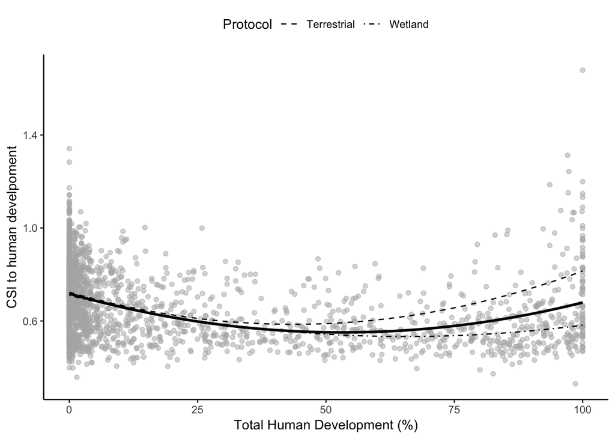

# 4. How does the proportion of exotic species contribute to these patterns?

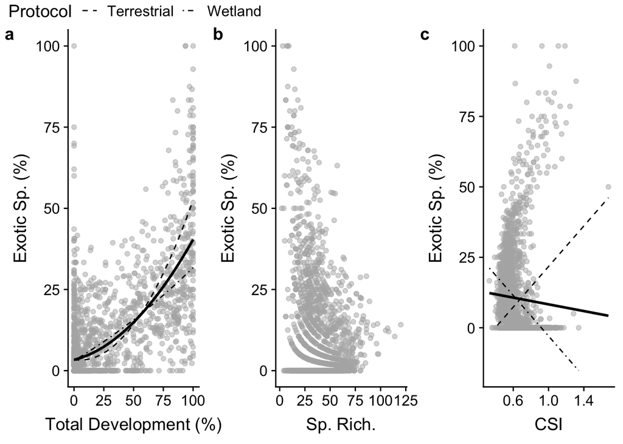

### 4.1 Richness

The best model describing species richness included `Protocol`, and an interaction between total development and the proportion of exotic species, but excluded `Latitude`, `Longitude`, and `Year`. The fixed effects of this model explained 0.21 proportion of the variation in richness; the fixed + random effects (i.e. site ID) explained 0.69 proportion of the variation.

Qualitatively, we again see that sites with a high proportion of exotic species are clusted ar the high end of the human development gradient, and have particularly low species richness.

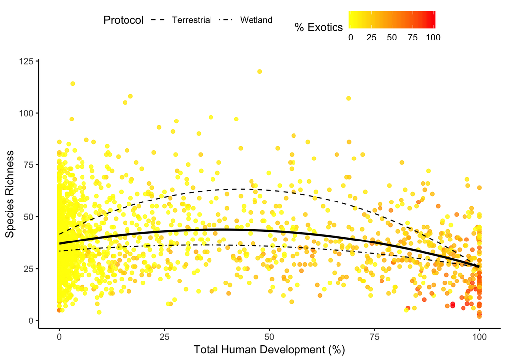

### 4.2 CSI

The best model of CSI included an interaction between human development and the proportion of exotics. The fixed effects of this model explained 0.2 proportion of the variation in richness; the fixed + random effects (i.e. site ID) explained 0.82 proportion of the variation.

Qualitatively, we again see that sites with a high proportion of exoric species are found at the high end of the development gradient, and these sites have particularly high specialization. Note that the proportion of exotic species is a stronger determinant of CSI than of species richness.

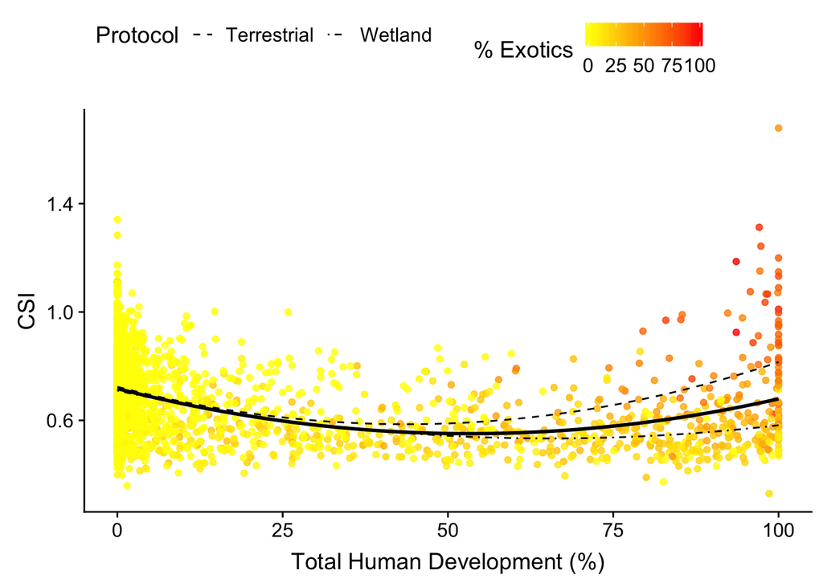

# 5. Additional stats and To Do

To do:

- check about including rotation in model
- check that site IDs were collapsed properly when adding lat/long; eg I site 100B coordinates from site 100. Note that in some cases, up to 6 distinct sites were assigned the same coordinates.